# Weight Lifting Machine Learning

# Abstract

Companies such as JawBone, Nike, and FitBit have produced a set of wearable accelerometers, useful for determining how well weightlifters perform proper movements when exercising. As an experiment, six weightlifters were asked to use a set of accelerometers and perform certain lifts in correct and incorrect ways. Consequently, the data from the accelerometers can potentially be used to assess the weightlifting form of other users wearing the accelerometers. This paper discusses two potential models for predicting what specific set of movements a weightlifter may be performing based upon accelerometer measurements-a decision tree model and a random forest model. The decision tree model was not a useful model, but the random forest model produced excellent results.

# Discussion

To generate the model discussed in this paper, the caret and randomForest R libraries were used.

```r
library(caret)
library(randomForest)
```

The training data contained 19,622 observations, each assigned to one of five types of lifting motions. The data contain 160 variables, but many variables were removed before processing for two reasons. The first reason was that some variables were merely metadata that were not relevant to generating a model. The other reason is that some variables were mostly missing values, as those variables were really summaries of many other rows of data. Consequently, they did not contain data for every observation, and inclusion of those variables in the final model would be misleading.

```r
#Read in the training CSV
mydf <- read.csv("pml-training.csv", header=TRUE, na.strings = c("NA", ""))

#Filter out the non-data columns
mydf <- mydf[,8:ncol(mydf)]

#Filter out the "summary" columns that do not contain data for every row
mydf <- mydf[,colSums(is.na(mydf))==0]
```

The classe variable contained the information that the model was intended to predict: the specific set of motions the test subject was asked to perform for that observation.

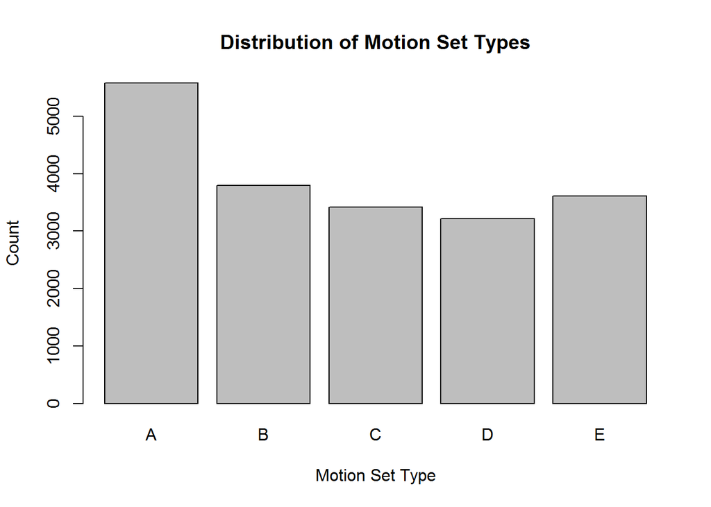

Though there are significantly more motion sets of class “A” than the other classes, each class appears more than 3000 times in the dataset. Consequently, any model trained on a subset of the data is likely to have enough representative rows from each class to be trained effectively.

```r
#Set a seed
set.seed(1000)

#Partition the data into training and testing sets
inTrain <- createDataPartition(y=mydf$classe,p=0.7,list=FALSE)
training <- mydf[inTrain,]
testing <- mydf[-inTrain,]
```

The data were partitioned into training (70%) and testing (30%) sets.

# Decision Tree Model

```r
#Set the trainControl parameter to do 10-fold cross validation
tc <- trainControl("cv",10)

#Now create the model using all variables
modFit <- train(classe~., method="rpart", data=training)
modFit$finalModel
```

```
## n= 13737
##
## node), split, n, loss, yval, (yprob)
##       * denotes terminal node
##
##  1) root 13737 9831 A (0.28 0.19 0.17 0.16 0.18)
##    2) roll_belt< 130.5 12583 8688 A (0.31 0.21 0.19 0.18 0.11)
##      4) pitch_forearm< -33.95 1101    7 A (0.99 0.0064 0 0 0) *
##      5) pitch_forearm>=-33.95 11482 8681 A (0.24 0.23 0.21 0.2 0.12)
##       10) yaw_belt>=169.5 580   58 A (0.9 0.04 0 0.052 0.0086) *
##       11) yaw_belt< 169.5 10902 8274 B (0.21 0.24 0.22 0.2 0.13)
##         22) magnet_dumbbell_z< -93.5 1321  536 A (0.59 0.27 0.047 0.068 0.023) *
##         23) magnet_dumbbell_z>=-93.5 9581 7247 C (0.16 0.24 0.24 0.22 0.14)
##           46) pitch_belt< -42.95 571   86 B (0.012 0.85 0.088 0.028 0.023) *
##           47) pitch_belt>=-42.95 9010 6726 C (0.17 0.2 0.25 0.23 0.15)
##             94) magnet_dumbbell_y< 291.5 3951 2342 C (0.19 0.12 0.41 0.16 0.12) *
##             95) magnet_dumbbell_y>=291.5 5059 3572 D (0.14 0.26 0.13 0.29 0.17) *
##    3) roll_belt>=130.5 1154   11 E (0.0095 0 0 0 0.99) *
```

The partition tree model does not appear to be particularly accurate for the “A”, “C”, and “D” classes.

```r
#Test the model on the testing dataset.
predvals <- predict(modFit,testing)
confusionMatrix(predvals,testing$classe)
```

```
## Confusion Matrix and Statistics
##
##           Reference
## Prediction   A   B   C   D   E
##          A 992 196  27  32  14
##          B   5 195  25   5   7
##          C 344 204 697 333 219
##          D 330 544 277 594 354
##          E   3   0   0   0 488
##
## Overall Statistics
##
##                Accuracy : 0.504
##                  95% CI : (0.491, 0.517)
##     No Information Rate : 0.284
##     P-Value [Acc > NIR] : <2e-16
##
##                   Kappa : 0.383
##  Mcnemar's Test P-Value : <2e-16
##
## Statistics by Class:
##
##                      Class: A Class: B Class: C Class: D Class: E
## Sensitivity             0.593   0.1712    0.679    0.616   0.4510
## Specificity             0.936   0.9912    0.774    0.694   0.9994
## Pos Pred Value          0.787   0.8228    0.388    0.283   0.9939
## Neg Pred Value          0.853   0.8329    0.920    0.902   0.8899
## Prevalence              0.284   0.1935    0.174    0.164   0.1839
## Detection Rate          0.169   0.0331    0.118    0.101   0.0829
## Detection Prevalence    0.214   0.0403    0.305    0.357   0.0834
## Balanced Accuracy       0.764   0.5812    0.726    0.655   0.7252
```

The accuracy of this decision tree model is only 50.4%, a disappointing result.

# Random Forest Model

Next, a random forest model was created using all of the variables. Random Forests do not require separate cross validation procedures.

```r
#A random forest with all the variables.  randomForest does not require cross validation.
modFit <- randomForest(classe~.,data=training, ntree=500)
modFit
```

```
##
## Call:
##  randomForest(formula = classe ~ ., data = training, ntree = 500)
##                Type of random forest: classification
##                      Number of trees: 500
## No. of variables tried at each split: 7
##
##         OOB estimate of  error rate: 0.53%
## Confusion matrix:
##      A    B    C    D    E class.error
## A 3903    1    0    0    2    0.000768
## B   12 2642    4    0    0    0.006020
## C    0   17 2377    2    0    0.007930
## D    0    0   27 2223    2    0.012877
## E    0    0    1    5 2519    0.002376
```

The random forest model produced an extremely accurate classification of the training dataset.

```r
#Test it against the testing dataset.
predvals <- predict(modFit,testing)
confusionMatrix(predvals,testing$classe)
```

```
## Confusion Matrix and Statistics
##
##           Reference
## Prediction    A    B    C    D    E
##          A 1671    4    0    0    0
##          B    3 1134    6    0    0
##          C    0    1 1018   11    0
##          D    0    0    2  952    4
##          E    0    0    0    1 1078
##
## Overall Statistics
##
##                Accuracy : 0.995
##                  95% CI : (0.992, 0.996)
##     No Information Rate : 0.284
##     P-Value [Acc > NIR] : <2e-16
##
##                   Kappa : 0.993
##  Mcnemar's Test P-Value : NA
##
## Statistics by Class:
##
##                      Class: A Class: B Class: C Class: D Class: E
## Sensitivity             0.998    0.996    0.992    0.988    0.996
## Specificity             0.999    0.998    0.998    0.999    1.000
## Pos Pred Value          0.998    0.992    0.988    0.994    0.999
## Neg Pred Value          0.999    0.999    0.998    0.998    0.999
## Prevalence              0.284    0.194    0.174    0.164    0.184
## Detection Rate          0.284    0.193    0.173    0.162    0.183
## Detection Prevalence    0.285    0.194    0.175    0.163    0.183
## Balanced Accuracy       0.999    0.997    0.995    0.993    0.998
```

The accuracy of the random forest model on the testing dataset was 99.5%, an excellent result.

```r
#Get the table of variable importances
as.data.frame(modFit$importance[order(-modFit$importance),])
```

```
##                      modFit$importance[order(-modFit$importance), ]
## roll_belt                                                    887.64
## yaw_belt                                                     625.20
## magnet_dumbbell_z                                            534.15
## pitch_forearm                                                533.12
## pitch_belt                                                   490.76
## magnet_dumbbell_y                                            490.11
## roll_forearm                                                 396.92
## magnet_dumbbell_x                                            333.42
## roll_dumbbell                                                294.73
## accel_dumbbell_y                                             290.53
## accel_belt_z                                                 289.05
## magnet_belt_z                                                286.06
## magnet_belt_y                                                264.46
## accel_dumbbell_z                                             237.88
## accel_forearm_x                                              226.68
## roll_arm                                                     218.11
## gyros_belt_z                                                 212.68
## magnet_forearm_z                                             194.44
## magnet_arm_x                                                 185.57
## accel_dumbbell_x                                             183.79
## yaw_dumbbell                                                 183.24
## total_accel_dumbbell                                         182.41
## magnet_belt_x                                                173.36
## gyros_dumbbell_y                                             172.49
## accel_arm_x                                                  165.12
## yaw_arm                                                      164.63
## accel_forearm_z                                              162.80
## magnet_forearm_y                                             158.16
## magnet_forearm_x                                             156.24
## total_accel_belt                                             155.21
## magnet_arm_y                                                 155.18
## magnet_arm_z                                                 135.04
## pitch_arm                                                    124.84
## yaw_forearm                                                  123.14
## pitch_dumbbell                                               119.11
## accel_arm_y                                                  109.92
## gyros_arm_y                                                   97.34
## accel_forearm_y                                               96.56
## gyros_dumbbell_x                                              92.26
## accel_arm_z                                                   92.14
## gyros_arm_x                                                   91.83
## accel_belt_y                                                  89.19
## gyros_forearm_y                                               88.02
## accel_belt_x                                                  86.89
## gyros_belt_y                                                  77.10
## total_accel_forearm                                           73.51
## total_accel_arm                                               69.96
## gyros_belt_x                                                  68.99
## gyros_dumbbell_z                                              62.18
## gyros_forearm_z                                               59.69
## gyros_forearm_x                                               54.97
## gyros_arm_z                                                   42.34
```

The table shows us how important each variable is in the final model.

# Conclusion

The decision tree model demonstrated an accuracy of only 50.4%-better than a random classification, but not especially reliable or useful. The random forest model, however, was much more accurate, producing a classification accuracy of 99.5%. Further testing on additional data would be useful for improving the models ever further.